# Homework 2 - building an R package

Qinghua Li

02/04/2025

# Question 1 - build and document an R package

Take the `getT` function that you wrote for last weeks homework and put it into a R package called `bios735`. You should add this to your homework repository, so it looks like the directory structure drawn below. You will re-use `bios735` across multiple homeworks.

```
statcomp-yourgithub
|-- rpkg_HW1.html
|-- rpkg_HW1.Rmd
|-- rpkg_HW2.html
|-- rpkg_HW2.Rmd
|-- bios735
    |-- DESCRIPTION
    ...
```

Add the function `getT` to `bios735` and document its two arguments `x` and `f`, provide information about the output, add a description and details. Export the `getT` function. So in the end, you should be adding `.Rd` files to the `man` directory through the use of `devtools::document`. You should also update the `DESCRIPTION` file with your details. You can put whatever you like as the `Title` of your package and so on. Finally, build the package. Add the `.tar.gz` built package to your homework repository as well.

```
  library(usethis)
  library(Rcpp)
  library(devtools)

  create_package("bios735", roxygen = FALSE)
  path <- getwd()
  r_path <- paste0(path, "/bios735")
  load_all(r_path)
  document(r_path)

  build("bios735")
```

# Question 2 - add tests to your package

Use the *testthat* package to add tests to your package. The details of the tests are up to you, but you should have both some tests of the input to `getT`, for example, that `x` and `f` have consistent dimension. Also, the way we wrote `getT` assumes that there is equal sample size between the two levels of `f`: don’t bother making the function more general, but instead make sure that `f` indeed is a factor with two levels and that both levels have `little.n` number of samples. You should also have some tests that the function gives the expected output on a toy dataset. You can for example, simulate a few rows of data, and then check that `getT` gives the same answer as `t.test` with `var.equal=TRUE`. Remember to add the tests directory to your GitHub repository so that the graders can see it. You can try out your tests with `test_package` or `test_file`.

Finally, run `check(manual=TRUE)` from within your package. Make sure that it passes without error, including `checking tests ...` and put the output below:

[output not shown]

```r
path <- getwd()
r_path <- paste0(path, "/bios735")
devtools::check(r_path, manual = TRUE)
```

```
## ══ Documenting ═════════════════════════════════════════════════════════════════
```

```
## ℹ Updating bios735 documentation
## ℹ Loading bios735
```

```
##
## ══ Building ════════════════════════════════════════════════════════════════════
## Setting env vars:
## • CFLAGS    : -Wall -pedantic
## • CXXFLAGS  : -Wall -pedantic
## • CXX11FLAGS: -Wall -pedantic
## • CXX14FLAGS: -Wall -pedantic
## • CXX17FLAGS: -Wall -pedantic
## • CXX20FLAGS: -Wall -pedantic
## ── R CMD build ─────────────────────────────────────────────────────────────────
##          checking for file 'C:\Users\dmlqh\Documents\BIOS\Classes_PhD\BIOS735\HW\statcomp-2025-QhL-UNC\bios735/DESCRIPTION' ...  ✔  checking for file 'C:\Users\dmlqh\Documents\BIOS\Classes_PhD\BIOS735\HW\statcomp-2025-QhL-UNC\bios735/DESCRIPTION'
##       ─  preparing 'bios735':
##    checking DESCRIPTION meta-information ...     checking DESCRIPTION meta-information ...   ✔  checking DESCRIPTION meta-information
## ─  cleaning src
##       ─  checking for LF line-endings in source and make files and shell scripts
##   ─  checking for empty or unneeded directories
##    Removed empty directory 'bios735/src'
##   ─  building 'bios735_0.0.0.1.tar.gz'
##
## ══ Checking ════════════════════════════════════════════════════════════════════
## Setting env vars:
## • _R_CHECK_CRAN_INCOMING_REMOTE_               : FALSE
## • _R_CHECK_CRAN_INCOMING_                      : FALSE
## • _R_CHECK_FORCE_SUGGESTS_                     : FALSE
## • _R_CHECK_PACKAGES_USED_IGNORE_UNUSED_IMPORTS_: FALSE
## • NOT_CRAN                                     : true
## ── R CMD check ─────────────────────────────────────────────────────────────────
##       ─  using log directory 'C:/Users/dmlqh/AppData/Local/Temp/RtmpsHYLFH/file9c05e36413d/bios735.Rcheck'
## ─  using R version 4.4.1 (2024-06-14 ucrt)
## ─  using platform: x86_64-w64-mingw32
## ─  R was compiled by
##        gcc.exe (GCC) 13.2.0
##        GNU Fortran (GCC) 13.2.0
##   ─  running under: Windows 10 x64 (build 19045)
## ─  using session charset: UTF-8
## ─  using option '--as-cran'
## ✔  checking for file 'bios735/DESCRIPTION'
## ─  this is package 'bios735' version '0.0.0.1'
## ─  package encoding: UTF-8
## ✔  checking package namespace information
```

[output cut: 34 more lines]

```
##    checking for code/documentation mismatches ...     checking for code/documentation mismatches ...   ✔  checking for code/documentation mismatches (682ms)
##    checking Rd \usage sections ...     checking Rd \usage sections ...   ✔  checking Rd \usage sections (554ms)
##    checking Rd contents ...     checking Rd contents ...   ✔  checking Rd contents
##    checking for unstated dependencies in examples ...     checking for unstated dependencies in examples ...   ✔  checking for unstated dependencies in examples
##      checking examples ...     checking examples ...   ✔  checking examples (702ms)
##      checking for unstated dependencies in 'tests' ...     checking for unstated dependencies in 'tests' ...   ✔  checking for unstated dependencies in 'tests'
##    checking tests ...  ─  checking tests
##      Running 'testthat.R'        ✔  Running 'testthat.R' (1.8s)
##      checking PDF version of manual ...     checking PDF version of manual ...   ✔  checking PDF version of manual (3.8s)
##      checking HTML version of manual ...     checking HTML version of manual ...   ✔  checking HTML version of manual (401ms)
##   ✔  checking for non-standard things in the check directory
## ✔  checking for detritus in the temp directory
##
##
##
```

```
## ── R CMD check results ──────────────────────────────────── bios735 0.0.0.1 ────
## Duration: 23.4s
##
## 0 errors ✔ | 0 warnings ✔ | 0 notes ✔
```

# Question 3 - short debugging example

The last question is a short one. You should (temporarily) add a bug to `getT`, which can be a either a bug that produces an error or a silent bug which creates some kind of erroneous output. Then use one of the debugging methods presented in the lecture to get to this point in the code when calling the function, and examine the variables at that point in the code, e.g. `ls()` and using `head`. Take a screenshot of the debugging environment and add this screenshot to your GitHub repository.

I temporarily removed a “,” when calculating row sum for x in the getT function. Below are pictures of using traceback() and options(error = recover) for code debugging.

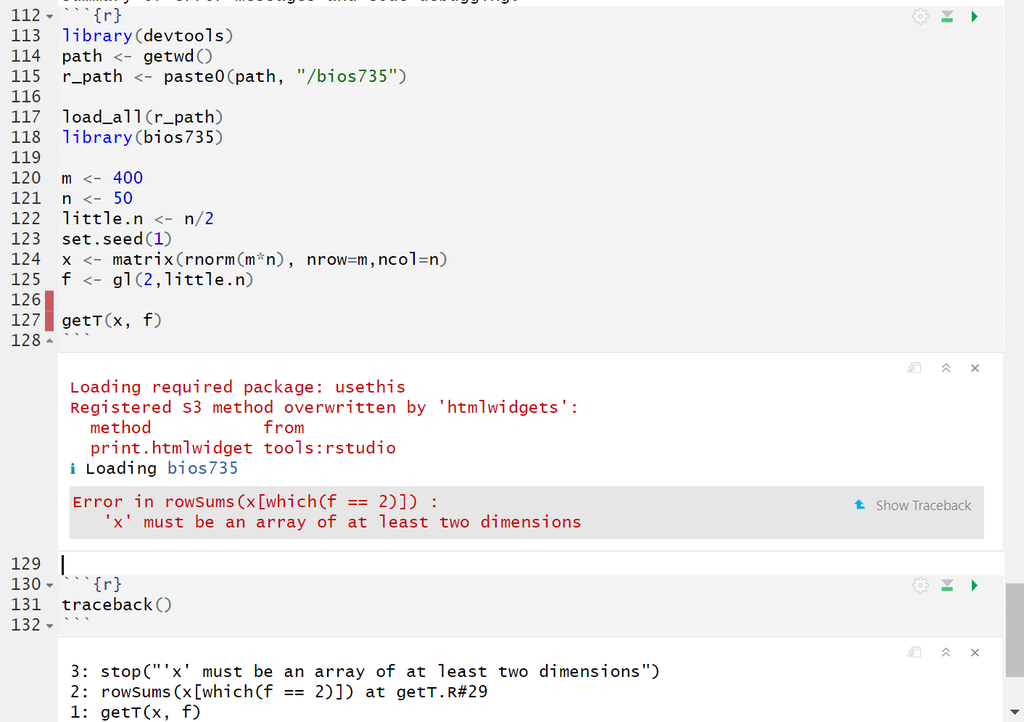

Debugging Screenshot

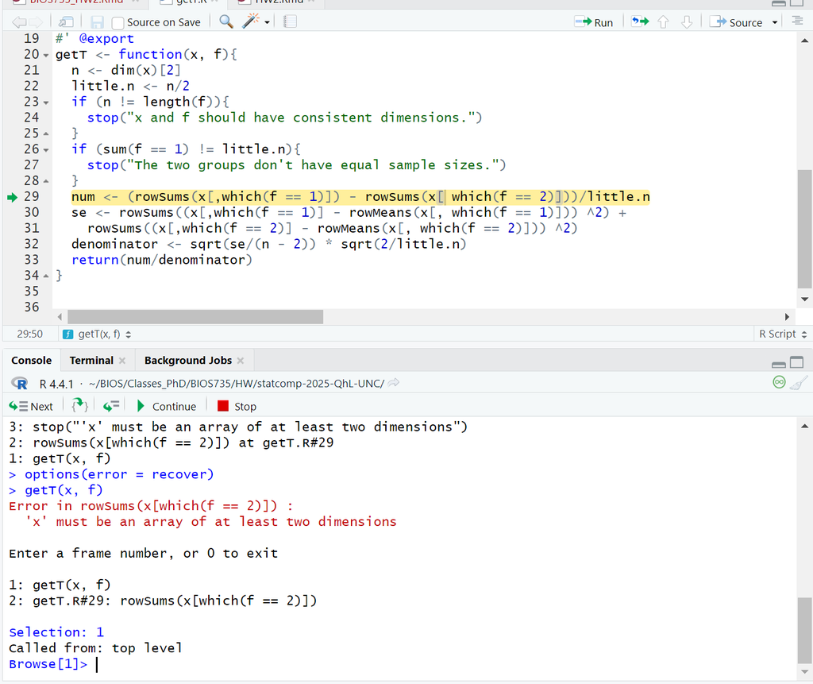

“Debugging Console”